# Graphs in Python: Bar Plots from a Pandas Data Frame

⇦ Back

# 1 Example Data

For this example we’ll use a ‘toy dataset’ (a small, freely available dataset which is realistic enough to be useful but not detailed enough to be academically insightful). Specifically, we’ll use the **diabetes dataset** which contains data from 442 diabetes patients (more information [here](https://scikit-learn.org/stable/datasets/toy_dataset.html#diabetes-dataset) and [here](https://www4.stat.ncsu.edu/~boos/var.select/diabetes.html). Download this from the internet as *tab–separated values* and convert it into a Pandas data frame as follows:

```python
import pandas as pd

# Download the tab-separated values from the internet
df = pd.read_csv('https://www4.stat.ncsu.edu/~boos/var.select/diabetes.tab.txt', sep='\t')

print(df.head())
```

```
##    AGE  SEX   BMI     BP   S1     S2    S3   S4      S5  S6    Y
## 0   59    2  32.1  101.0  157   93.2  38.0  4.0  4.8598  87  151
## 1   48    1  21.6   87.0  183  103.2  70.0  3.0  3.8918  69   75
## 2   72    2  30.5   93.0  156   93.6  41.0  4.0  4.6728  85  141
## 3   24    1  25.3   84.0  198  131.4  40.0  5.0  4.8903  89  206
## 4   50    1  23.0  101.0  192  125.4  52.0  4.0  4.2905  80  135
```

For this example, we’ll only use the age, BMI and ‘S6’ columns. According to the documentation for this dataset, column S6 represents a measure of blood sugar called ‘glu’ which I think is meant to be *fasting blood sugar* (measured in mg/dL) although, given that these patients are diabetic, the numbers are unexpectedly low. We’ll use them anyway:

```python
# Rename
df = df.rename(columns={'S6': 'GLU'})
# Assume the variable is fasting blood sugar, measured in mg/dL

# Trim
cols = ['AGE', 'BMI', 'GLU']
df = df[cols]

print(df.head())
```

```
##    AGE   BMI  GLU
## 0   59  32.1   87
## 1   48  21.6   69
## 2   72  30.5   85
## 3   24  25.3   89
## 4   50  23.0   80
```

# 2 Categorise the Data

We’re going to see if there is a relationship between blood sugar level and BMI of these diabetic patients. To do that, we need to classify the data into groups using the BMI values:

- Normal: 18.5 to 24.9 kg/m²
- Overweight: 25.0 to 29.9 kg/m²
- Obese: 30.0+ kg/m²

This is done below in 3 steps:

- The edges of the three ‘bins’ (ranges) of values are defined
- The ‘labels’ (names) of the categories are defines
- The BMI values are ‘cut’ up (sorted) into the three categories, specifying that the rightmost edges of the bins are not included in those bins (ie the rightmost edge of the ‘normal’ bin - 25 kg/m² - is part of the ‘overweight’ bin and the rightmost edge of the ‘overweight’ bin - 30 kg/m² - is part of the ‘obese’ bin)

```python
# Categorise the BMI data
bins = [0, 25, 30, df['BMI'].max() + 1]
labels = ['Normal', 'Overweight', 'Obese']
df['category'] = pd.cut(df['BMI'], bins, labels=labels, right=False)

print(df.head())
```

```
##    AGE   BMI  GLU    category
## 0   59  32.1   87       Obese
## 1   48  21.6   69      Normal
## 2   72  30.5   85       Obese
## 3   24  25.3   89  Overweight
## 4   50  23.0   80      Normal
```

Let’s see how many people in each category have high blood sugar levels (≥90 mg/dL in this example, in real life this is well within normal):

```python
# Find the number of ppts with glu >= 90 mg/dL
print(df[(df['category'] == 'Normal') & (df['GLU'] >= 90)].shape[0])
print(df[(df['category'] == 'Overweight') & (df['GLU'] >= 90)].shape[0])
print(df[(df['category'] == 'Obese') & (df['GLU'] >= 90)].shape[0])
```

```
## 80
## 100
## 71
```

# 3 Get Sample Sizes and Averages

For each category, we want to know the mean glu value and the number of patients. This can be done by **pivoting** the table:

```python
# Calculate the mean of each category
df = pd.pivot_table(df, values='GLU', aggfunc=['mean', 'count'], index='category')

print(df)
```

```
##                  mean count
##                   GLU   GLU
## category
## Normal      87.021277   188
## Overweight  92.387097   155
## Obese       97.545455    99
```

Remove the ‘GLU’ level:

```python
# Remove the 'GLU' level
df.columns = df.columns.droplevel(level=1)

print(df)
```

```
##                  mean  count
## category
## Normal      87.021277    188
## Overweight  92.387097    155
## Obese       97.545455     99
```

Now we can create the bar plot!

# 4 Simple Bar Plot

A bar plot can be created directly from a Pandas data frame using the `plot.bar()` method:

- Our x-data is the index column of our data frame, so use the `use_index=True` parameter
- Our y-data is the mean of the glu values: `y='mean'`
- We don’t want the category labels to be rotated: `rot=0`
- We can customise the colour of the bars via the `color` keyword argument

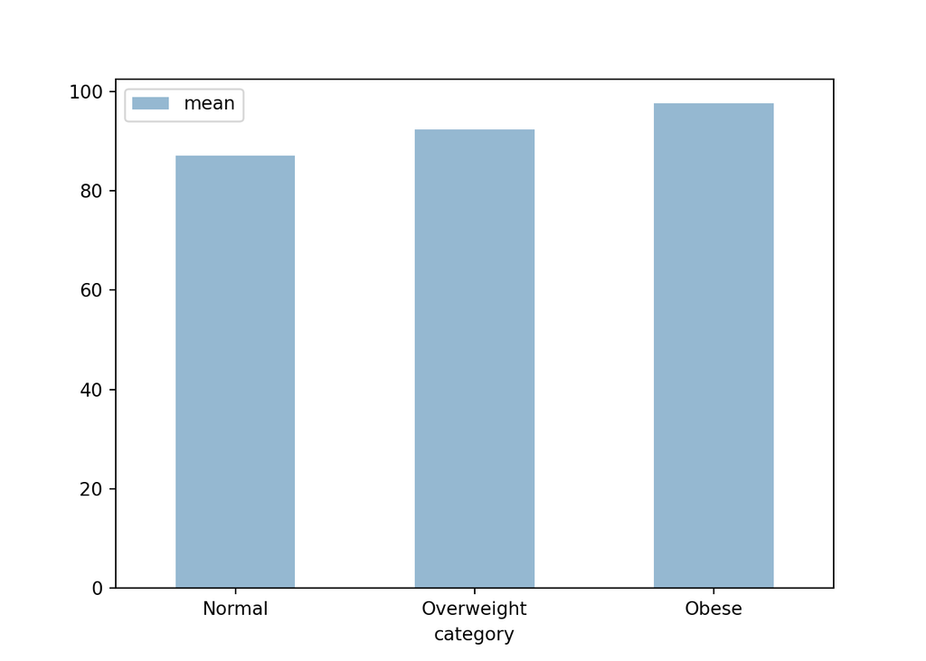

```python
import matplotlib.pyplot as plt

# Create bar plot
ax = df.plot.bar(use_index=True, y='mean', rot=0, color='#95b8d1')

plt.show()
```

# 5 Format Edits

Let’s make the following changes:

- Set the Matplotlib runtime command (‘rc’) values so as to:
  - Change the figure size: `plt.rc('figure', figsize=...)`
  - Use Latex for the text: `plt.rc('text', usetex=True)`
  - Use the serif font: `plt.rc('font', family='serif')`
  - Import a Latex package so as to be able to use Greek letters: `plt.rc('text.latex', preamble=r'\usepackage{textgreek}')`
- Set the title of the graph by using `set_title()`
  - Use an f-string (formatted string) to include the total sample size, formatted as a decimal with a comma as the thousands separator (`,d`)
  - Use an r-string (raw string) to allow it to be interpreted by Latex. That allows you to use Latex commands, eg to change the fontsize via `\footnotesize`
  - A string can be an f-string and an r-string at the same time, ie an ‘fr-string’ or an ‘rf-string’ (both work)
- Set the axis labels using `set_xlabel()` and `set_ylabel()`
  - The units for this measurement of blood sugar are ‘mg/dL’ but I’m going to change that to ‘1000 μg/dL’ so I can demonstrate using Greek letters in labels (which is something that the textgreek Latex package allows me to do)
- Change the vertical zoom of the graph using `set_ylim()`
- Remove the legend using `legend().set_visible(False)`

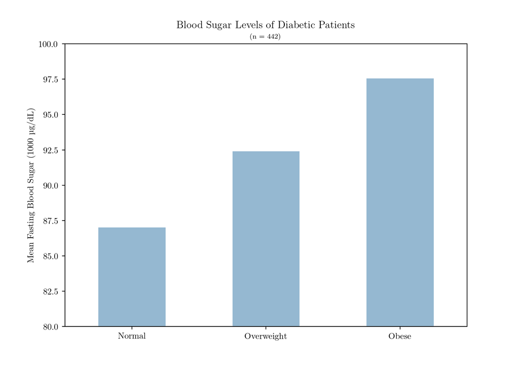

```python
# Matplotlib settings
A = 5  # Want figures to be A5
plt.rc('figure', figsize=[46.82 * .5**(.5 * A), 33.11 * .5**(.5 * A)])
plt.rc('text', usetex=True)
plt.rc('font', family='serif')
plt.rc('text.latex', preamble=r'\usepackage{textgreek}')

# Create bar plot
ax = df.plot.bar(use_index=True, y='mean', rot=0, color='#95b8d1')
# Format the plot
total_sample_size = df['count'].sum()
ax.set_title(
    'Blood Sugar Levels of Diabetic Patients\n' +
    rf'\footnotesize (n = {total_sample_size:,d})'
)
ax.set_xlabel('')
ax.set_ylabel(r'Mean Fasting Blood Sugar (1000 \textmu g/dL)')
ax.set_ylim([80, 100])
ax.legend().set_visible(False)

plt.show()
```

# 6 Annotations Outside the Plot

To make annotations outside the plot area, use the `text()` function and specify the y-position of the annotations to be outside the range of the plot:

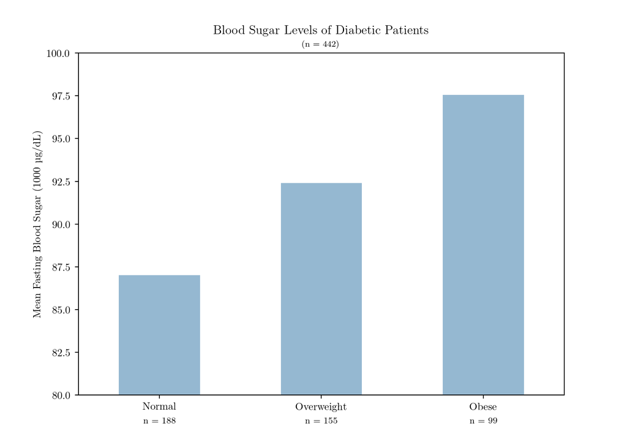

```python
# Set the keyword arguments for the text labels
kwargs = {'ha': 'center', 'va': 'center', 'size': 'small'}
# Annotate the sample size below each label
for i, bar in enumerate(ax.patches):
    # For each bar, add text that contains its sample size
    sample_size = df['count'].to_list()[i]
    ax.text(
        bar.get_x() + bar.get_width() / 2, 78.5,
        f'n = {sample_size:d}', **kwargs
    )
```

# 7 Highlight Information

You could separate sections of the bars out to represent their height above 90 mg/dL:

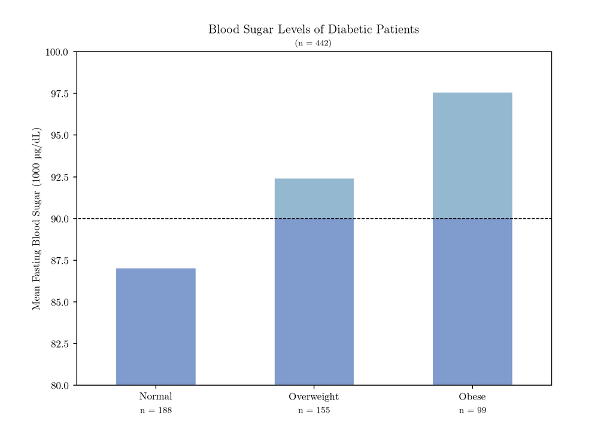

```python
# Add bar plots of different colour
x_positions = [0, 1, 2]
heights = [ax.patches[0].get_height(), 90, 90]
width = 0.5
ax.bar(x_positions, heights, width, color='#809bce')
# Add horizontal line
ax.plot([-1, 2.5], [90, 90], 'k--', lw=0.8)
```

# 8 Annotations Inside the Plot

To make annotations inside the plot area, use the `text()` function and specify the y-positions of the annotations to be inside the range of the plot:

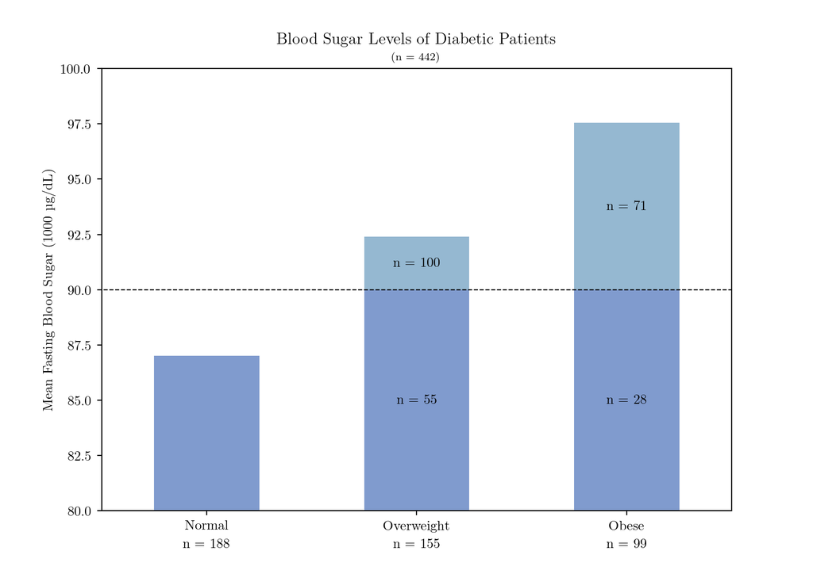

```python
# Add text of number who have glu >= 90 mg/dL
ax.text(1, (92.39 - 90) / 2 + 90, 'n = 100', **kwargs)
ax.text(1, 85, 'n = 55', **kwargs)
ax.text(2, (97.53 - 90) / 2 + 90, 'n = 71', **kwargs)
ax.text(2, 85, 'n = 28', **kwargs)
```

# 9 Save the Plot

Use `plt.savefig('name_of_plot.png')` to save the plot to your computer. The .png, .jpg and .pdf extensions should work, as well as others. Alternatively, display the plot in a pop-up window with `plt.show()`. If you are plotting more than one figure in the same Python script use `plt.figure()` and `plt.close()` before and after each, respectively, in order to tell Python when one plot ends and the next one starts.

⇦ Back